# Amazon sales project

Amazon Sales Analysis

About the Dataset

The Amazon sales Dataset includes comprehensive transactional data about product sales made online through Amazon India. Order ID, order date, order status, fulfillment method (Amazon or Merchant), sales channel, shipping service level, product details (style, SKU, category, size, ASIN), quantity sold, transaction amount in Indian rupees, and customer shipping location (city, state, postal code, and country) are among the 24 attributes and 129,175 records that make up this system. The dataset can be used to analyze sales performance, customer purchasing patterns, product demand patterns, and regional sales trends because it also contains logistics and operational variables like courier status, promotion IDs, B2B indicator, and fulfillment type. All things considered, this dataset offers a thorough understanding of Amazon's sales operations and is perfect for Python-based univariate, bivariate, and multivariate data analysis.

```python
# IMPORT THE LIBRARIES
import pandas as pd
import numpy as np
import matplotlib.pyplot as plt
import seaborn as sns
```

```python
# LOAD THE DATASET
data=pd.read_csv(r"C:\Users\user\Downloads\Cleaned Amazon Sale Report.csv",low_memory=False)
```

```python
# REVIEW THE DATA
data
```

|  | index | order_id | parsed_date | status | fulfillment | sales_channel | ship_service_level | style | sku | category | ... | currency | amount | ship_city | ship_state | ship_postal_code | ship_country | promotion_ids | is_b2b | fulfilled_by | unnamed_cols |
| --- | --- | --- | --- | --- | --- | --- | --- | --- | --- | --- | --- | --- | --- | --- | --- | --- | --- | --- | --- | --- | --- |
| 0 | 96150 | 408-4631753-5605964 | 25-06-2022 | pending | amazon | amazon.in | expedited | BTM003 | BTM003-B-L | bottom | ... | INR | 0.0 | MUMBAI SUBUEBAN | Maharashtra | 400066.0 | IN | NaN | False | NaN | False |
| 1 | 91239 | 404-2093011-6135513 | 29-06-2022 | pending | merchant | amazon.in | standard | J0062 | J0062-DR-M | western dress | ... | INR | 475.0 | SOUTH 24 PARGANAS | West Bengal | 743329.0 | IN | Amazon PLCC Free-Financing Universal Merchant ... | False | easy ship | False |
| 2 | 91223 | 407-7926766-7601961 | 29-06-2022 | pending | amazon | amazon.in | expedited | J0097 | J0097-KR-M | kurta | ... | INR | 544.0 | MUMBAI SUBUEBAN | Maharashtra | 400095.0 | IN | NaN | False | NaN | False |
| 3 | 91459 | 402-1067136-1825927 | 29-06-2022 | pending | merchant | amazon.in | standard | J0097 | J0097-KR-S | kurta | ... | INR | NaN | NORTH 24 PARGANAS | West Bengal | 700135.0 | IN | Amazon PLCC Free-Financing Universal Merchant ... | False | easy ship | False |
| 4 | 91662 | 403-9219853-4911569 | 29-06-2022 | pending | merchant | amazon.in | standard | J0097 | J0097-KR-S | kurta | ... | INR | 544.0 | ARARIA | Bihar | 854318.0 | IN | Amazon PLCC Free-Financing Universal Merchant ... | False | easy ship | False |
| ... | ... | ... | ... | ... | ... | ... | ... | ... | ... | ... | ... | ... | ... | ... | ... | ... | ... | ... | ... | ... | ... |
| 129170 | 99061 | 171-6340992-2821157 | 22-06-2022 | shipped | amazon | amazon.in | expedited | JNE3718 | JNE3718-KR-XS | kurta | ... | INR | 458.0 | KANCHIPURAM | Tamil Nadu | 603319.0 | IN | Duplicated A12RHGVGRWOT3S 1560498941486 | False | NaN | False |
| 129171 | 105590 | 407-1443347-3957965 | 17-06-2022 | shipped | amazon | amazon.in | expedited | JNE3718 | JNE3718-KR-XS | kurta | ... | INR | 458.0 | BELAGAVI | Karnataka | 590003.0 | IN | IN Core Free Shipping 2015/04/08 23-48-5-108 | False | NaN | False |
| 129172 | 120935 | 407-2595717-5074750 | 06-06-2022 | shipped | amazon | amazon.in | expedited | JNE3718 | JNE3718-KR-XS | kurta | ... | INR | 458.0 | NIZAMABAD | Telangana | 503003.0 | IN | NaN | False | NaN | False |
| 129173 | 123242 | 408-8212685-4881149 | 05-06-2022 | shipped | amazon | amazon.in | expedited | JNE3718 | JNE3718-KR-XS | kurta | ... | INR | 458.0 | MUMBAI SUBUEBAN | Maharashtra | 400092.0 | IN | NaN | False | NaN | False |
| 129174 | 109224 | 403-9208822-6513169 | 14-06-2022 | shipped | amazon | amazon.in | expedited | JNE3719 | JNE3719-KR-XL | kurta | ... | INR | 399.0 | BENGALURU | Karnataka | 560105.0 | IN | IN Core Free Shipping 2015/04/08 23-48-5-108 | False | NaN | False |

129175 rows × 24 columns

UNIVARIATE ANALYSIS

```python
data.head()
```

|  | index | order_id | parsed_date | status | fulfillment | sales_channel | ship_service_level | style | sku | category | ... | currency | amount | ship_city | ship_state | ship_postal_code | ship_country | promotion_ids | is_b2b | fulfilled_by | unnamed_cols |
| --- | --- | --- | --- | --- | --- | --- | --- | --- | --- | --- | --- | --- | --- | --- | --- | --- | --- | --- | --- | --- | --- |
| 0 | 96150 | 408-4631753-5605964 | 25-06-2022 | pending | amazon | amazon.in | expedited | BTM003 | BTM003-B-L | bottom | ... | INR | 0.0 | MUMBAI SUBUEBAN | Maharashtra | 400066.0 | IN | NaN | False | NaN | False |
| 1 | 91239 | 404-2093011-6135513 | 29-06-2022 | pending | merchant | amazon.in | standard | J0062 | J0062-DR-M | western dress | ... | INR | 475.0 | SOUTH 24 PARGANAS | West Bengal | 743329.0 | IN | Amazon PLCC Free-Financing Universal Merchant ... | False | easy ship | False |
| 2 | 91223 | 407-7926766-7601961 | 29-06-2022 | pending | amazon | amazon.in | expedited | J0097 | J0097-KR-M | kurta | ... | INR | 544.0 | MUMBAI SUBUEBAN | Maharashtra | 400095.0 | IN | NaN | False | NaN | False |
| 3 | 91459 | 402-1067136-1825927 | 29-06-2022 | pending | merchant | amazon.in | standard | J0097 | J0097-KR-S | kurta | ... | INR | NaN | NORTH 24 PARGANAS | West Bengal | 700135.0 | IN | Amazon PLCC Free-Financing Universal Merchant ... | False | easy ship | False |
| 4 | 91662 | 403-9219853-4911569 | 29-06-2022 | pending | merchant | amazon.in | standard | J0097 | J0097-KR-S | kurta | ... | INR | 544.0 | ARARIA | Bihar | 854318.0 | IN | Amazon PLCC Free-Financing Universal Merchant ... | False | easy ship | False |

5 rows × 24 columns

```python
data.tail()
```

|  | index | order_id | parsed_date | status | fulfillment | sales_channel | ship_service_level | style | sku | category | ... | currency | amount | ship_city | ship_state | ship_postal_code | ship_country | promotion_ids | is_b2b | fulfilled_by | unnamed_cols |
| --- | --- | --- | --- | --- | --- | --- | --- | --- | --- | --- | --- | --- | --- | --- | --- | --- | --- | --- | --- | --- | --- |
| 129170 | 99061 | 171-6340992-2821157 | 22-06-2022 | shipped | amazon | amazon.in | expedited | JNE3718 | JNE3718-KR-XS | kurta | ... | INR | 458.0 | KANCHIPURAM | Tamil Nadu | 603319.0 | IN | Duplicated A12RHGVGRWOT3S 1560498941486 | False | NaN | False |
| 129171 | 105590 | 407-1443347-3957965 | 17-06-2022 | shipped | amazon | amazon.in | expedited | JNE3718 | JNE3718-KR-XS | kurta | ... | INR | 458.0 | BELAGAVI | Karnataka | 590003.0 | IN | IN Core Free Shipping 2015/04/08 23-48-5-108 | False | NaN | False |
| 129172 | 120935 | 407-2595717-5074750 | 06-06-2022 | shipped | amazon | amazon.in | expedited | JNE3718 | JNE3718-KR-XS | kurta | ... | INR | 458.0 | NIZAMABAD | Telangana | 503003.0 | IN | NaN | False | NaN | False |
| 129173 | 123242 | 408-8212685-4881149 | 05-06-2022 | shipped | amazon | amazon.in | expedited | JNE3718 | JNE3718-KR-XS | kurta | ... | INR | 458.0 | MUMBAI SUBUEBAN | Maharashtra | 400092.0 | IN | NaN | False | NaN | False |
| 129174 | 109224 | 403-9208822-6513169 | 14-06-2022 | shipped | amazon | amazon.in | expedited | JNE3719 | JNE3719-KR-XL | kurta | ... | INR | 399.0 | BENGALURU | Karnataka | 560105.0 | IN | IN Core Free Shipping 2015/04/08 23-48-5-108 | False | NaN | False |

5 rows × 24 columns

These functions are used to view the first or last few rows of the dataset. They help in understanding the structure of the data, such as column names, data types, and sample values. This step is important at the beginning of analysis to ensure the data has been loaded correctly. It also gives a quick idea of whether the dataset contains categorical or numerical variables. Using this function helps identify obvious data issues early. It is mainly used for data familiarization.

```python
# CHECK DATA TYPE
type(data)
```

```
pandas.core.frame.DataFrame
```

```python
# CHECK DATA SHAPE(ROWS,COLUMNS) also known as-- (Records,Fields)
data.shape
```

```
(129175, 24)
```

The df.shape function provides the total number of fields(columns) and records(rows) in the dataset. This step is important for understanding data structure and selecting appropriate analysis and visualization techniques.

```python
# CHECK DATA TO FIND THE NULL VALUES AND DATATYPES OF COLUMNS IN THE DATA
data.info()
```

```
<class 'pandas.core.frame.DataFrame'>
RangeIndex: 129175 entries, 0 to 129174
Data columns (total 24 columns):
 #   Column              Non-Null Count   Dtype
---  ------              --------------   -----
 0   index               129175 non-null  int64
 1   order_id            129175 non-null  object
 2   parsed_date         129175 non-null  object
 3   status              129175 non-null  object
 4   fulfillment         129175 non-null  object
 5   sales_channel       129175 non-null  object
 6   ship_service_level  129175 non-null  object
 7   style               129175 non-null  object
 8   sku                 129175 non-null  object
 9   category            129175 non-null  object
```

[output cut: 16 more lines]

This function provides a concise summary of the dataset including number of rows, columns, data types, and non-null values. It is very useful for identifying missing values and understanding which columns are numerical or categorical. This helps in deciding which analysis and visualizations can be applied to each column. It also assists in data cleaning decisions such as type conversion. Overall, it gives a technical overview of the dataset.

```python
# TO CHECK THE STATISTICAL VALUE OF THE DATA
data.describe(include="all").T
```

|  | count | unique | top | freq | mean | std | min | 25% | 50% | 75% | max |
| --- | --- | --- | --- | --- | --- | --- | --- | --- | --- | --- | --- |
| index | 129175.0 | NaN | NaN | NaN | 64473.978587 | 37232.871455 | 0.0 | 32229.5 | 64464.0 | 96717.5 | 128974.0 |
| order_id | 129175 | 120378 | 171-5057375-2831560 | 12 | NaN | NaN | NaN | NaN | NaN | NaN | NaN |
| parsed_date | 129175 | 91 | 03-05-2022 | 2088 | NaN | NaN | NaN | NaN | NaN | NaN | NaN |
| status | 129175 | 13 | shipped | 78004 | NaN | NaN | NaN | NaN | NaN | NaN | NaN |
| fulfillment | 129175 | 2 | amazon | 89898 | NaN | NaN | NaN | NaN | NaN | NaN | NaN |
| sales_channel | 129175 | 2 | amazon.in | 129051 | NaN | NaN | NaN | NaN | NaN | NaN | NaN |
| ship_service_level | 129175 | 2 | expedited | 88812 | NaN | NaN | NaN | NaN | NaN | NaN | NaN |
| style | 129175 | 1377 | JNE3797 | 4224 | NaN | NaN | NaN | NaN | NaN | NaN | NaN |
| sku | 129175 | 7195 | JNE3797-KR-L | 773 | NaN | NaN | NaN | NaN | NaN | NaN | NaN |
| category | 129175 | 9 | set | 50284 | NaN | NaN | NaN | NaN | NaN | NaN | NaN |
| size | 129175 | 11 | M | 22711 | NaN | NaN | NaN | NaN | NaN | NaN | NaN |
| asin | 129175 | 7190 | B09SDXFFQ1 | 773 | NaN | NaN | NaN | NaN | NaN | NaN | NaN |
| courier_status | 121556 | 3 | shipped | 109061 | NaN | NaN | NaN | NaN | NaN | NaN | NaN |
| qty | 129175.0 | NaN | NaN | NaN | 1.431856 | 7.21957 | 0.0 | 1.0 | 1.0 | 1.0 | 100.0 |
| currency | 121380 | 1 | INR | 121380 | NaN | NaN | NaN | NaN | NaN | NaN | NaN |
| amount | 120995.0 | NaN | NaN | NaN | 696.638219 | 4935.259488 | 0.0 | 449.0 | 605.0 | 788.0 | 889900.0 |
| ship_city | 127820 | 685 | BENGALURU | 12339 | NaN | NaN | NaN | NaN | NaN | NaN | NaN |
| ship_state | 128092 | 36 | Maharashtra | 22009 | NaN | NaN | NaN | NaN | NaN | NaN | NaN |
| ship_postal_code | 129142.0 | NaN | NaN | NaN | 464021.300669 | 191439.334782 | 110001.0 | 382421.0 | 500033.0 | 600024.0 | 989898.0 |
| ship_country | 129142 | 1 | IN | 129142 | NaN | NaN | NaN | NaN | NaN | NaN | NaN |
| promotion_ids | 79933 | 5787 | IN Core Free Shipping 2015/04/08 23-48-5-108 | 46206 | NaN | NaN | NaN | NaN | NaN | NaN | NaN |
| is_b2b | 129175 | 2 | False | 128303 | NaN | NaN | NaN | NaN | NaN | NaN | NaN |
| fulfilled_by | 39277 | 1 | easy ship | 39277 | NaN | NaN | NaN | NaN | NaN | NaN | NaN |
| unnamed_cols | 80026 | 1 | False | 80026 | NaN | NaN | NaN | NaN | NaN | NaN | NaN |

The describe() function generates statistical summaries such as mean, median, standard deviation, minimum, and maximum for numerical variables. It helps in understanding the distribution and spread of data. Outliers can be roughly identified by comparing minimum and maximum values. This function is essential for basic statistical understanding. It also helps in comparing variability across different variables. It is widely used in exploratory data analysis.

```python
# FUNCTION DEFINED TO FIND OUTLIERS
def check_outliers_iqr(df, col):
    Q1 = df[col].quantile(0.25)
    Q3 = df[col].quantile(0.75)
    IQR = Q3 - Q1

    lower = Q1 - 1.5 * IQR
    upper = Q3 + 1.5 * IQR

    outliers = df[(df[col] < lower) | (df[col] > upper)]

    print(f"{col}")
    print("Lower Bound:", lower)
    print("Upper Bound:", upper)
    print("Outlier Count:", outliers.shape[0])
    print("-" * 40)
```

Outliers are identified using the Interquartile Range (IQR) method. The first and third quartiles are calculated, and values outside the acceptable range are treated as outliers. This method is applied to individual numerical columns. Outliers can distort averages and trends. Detecting them improves analysis accuracy. It is a key univariate preprocessing step.

```python
# USED THE DEFINED FUNCTION
for col in ["amount", "qty"]:
    check_outliers_iqr(data, col)
```

```
amount
Lower Bound: -59.5
Upper Bound: 1296.5
Outlier Count: 3636
----------------------------------------
qty
Lower Bound: 1.0
Upper Bound: 1.0
Outlier Count: 13879
----------------------------------------
```

```python
# HANDLING THE OUTLIER BY CAPPING METHOD
def cap_outliers_iqr(df, col):
    Q1 = df[col].quantile(0.25)
    Q3 = df[col].quantile(0.75)
    IQR = Q3 - Q1
    lower = Q1 - 1.5 * IQR
    upper = Q3 + 1.5 * IQR

    df[col] = np.where(df[col] < lower, lower,
                       np.where(df[col] > upper, upper, df[col]))
```

```python
# USING THE ABOVE FUNCTION
for col in ["qty", "amount"]:
    cap_outliers_iqr(data, col)
```

After detecting outliers, they are removed or capped to maintain data consistency. This is done column-wise to avoid data distortion. Removing extreme values improves visualization clarity. It also enhances reliability of statistical measures. This step ensures robust analysis. It prepares the data for deeper exploration.

```python
# AGAIN CHECKING THE OUTLIERS REMOVED OR NOT
for col in ["amount", "qty"]:
    check_outliers_iqr(data, col)
```

```
amount
Lower Bound: -59.5
Upper Bound: 1296.5
Outlier Count: 0
----------------------------------------
qty
Lower Bound: 1.0
Upper Bound: 1.0
Outlier Count: 0
----------------------------------------
```

```python
# TO CHECK THE SUM OF NULL VALUES IN EACH COLUMN
data.isnull().sum()
```

```
index                     0
order_id                  0
parsed_date               0
status                    0
fulfillment               0
sales_channel             0
ship_service_level        0
style                     0
sku                       0
category                  0
size                      0
asin                      0
courier_status         7619
qty                       0
currency               7795
amount                 8180
ship_city              1355
ship_state             1083
ship_postal_code         33
ship_country             33
promotion_ids         49242
is_b2b                    0
fulfilled_by          89898
unnamed_cols          49149
dtype: int64
```

This function calculates the total number of missing values in each column. Missing data can negatively affect analysis and visualizations. This step helps identify columns requiring cleaning or imputation. It supports decisions like filling or removing missing values. Handling missing values improves data reliability. This is a core data-cleaning step.

```python
# TO DROP AND HANDLE THE NULL VALUES
data.drop(columns=['promotion_ids', 'unnamed_cols', 'fulfilled_by'], inplace=True)
```

The drop function removes rows or columns with missing values when necessary. These techniques are applied column-wise. Proper handling prevents bias in analysis. This step improves dataset quality. DROPPING THESE COLUMNS BECAUSE MORE THAN 30% - 40% MISSING VALUES PRESENT.EXCESSIVE MISSING VALUES CAN ADD NOISE.

```python
# TO REPLACE THE OBJECT TYPE VALUES WITH UNKNOWN
object_missing_values = [ 'courier_status', 'currency', 'ship_city', 'ship_state', 'ship_postal_code', 'ship_country' ]
data[object_missing_values] = data[object_missing_values].fillna('Unknown')
```

The fillna('Unknown') function replaces all missing values in these columns with the label “Unknown”. This approach is suitable for categorical data because statistical measures like mean or median cannot be applied. Replacing missing values ensures that no records are lost during analysis. It also maintains consistency in categorical analysis and avoids errors during grouping and visualization.

```python
# # REPLACE THE NUMERIC VALUES OF COLUMN AMOUNT WITH MEDIAN
data.fillna({'amount': data['amount'].median()}, inplace=True)
```

The median of the amount column is calculated and used to replace missing values. Median is preferred over mean because it is less affected by outliers, which are common in sales and transaction data. The inplace=True parameter ensures that changes are applied directly to the dataset without creating a new copy. This method helps preserve the overall distribution of sales values. Proper handling of missing numerical data improves the accuracy of further statistical analysis and visualizations.

```python
# CHECK AGAIN THE MISSING VALUES HANDLED CORRECTLY OR NOT
data.isnull().sum()
```

```
index                 0
order_id              0
parsed_date           0
status                0
fulfillment           0
sales_channel         0
ship_service_level    0
style                 0
sku                   0
category              0
size                  0
asin                  0
courier_status        0
qty                   0
currency              0
amount                0
ship_city             0
ship_state            0
ship_postal_code      0
ship_country          0
is_b2b                0
dtype: int64
```

```python
# TO FIND THE DUPLICATE VALUES
data.duplicated().sum()
```

```
200
```

This function is used to identify the total number of duplicate rows present in the dataset. The duplicated() method checks each row and compares it with previous rows to determine whether it has already appeared. The sum() function then counts the total number of True values, giving the exact number of duplicate records. Identifying duplicates is important because repeated entries can distort sales totals, averages, and overall analysis. This step helps ensure data accuracy before further analysis.

```python
# TO DROP THE DUPLICATE VALUES
data.drop_duplicates()
```

|  | index | order_id | parsed_date | status | fulfillment | sales_channel | ship_service_level | style | sku | category | ... | asin | courier_status | qty | currency | amount | ship_city | ship_state | ship_postal_code | ship_country | is_b2b |
| --- | --- | --- | --- | --- | --- | --- | --- | --- | --- | --- | --- | --- | --- | --- | --- | --- | --- | --- | --- | --- | --- |
| 0 | 96150 | 408-4631753-5605964 | 25-06-2022 | pending | amazon | amazon.in | expedited | BTM003 | BTM003-B-L | bottom | ... | B085Y4QB25 | unshipped | 1.0 | INR | 0.0 | MUMBAI SUBUEBAN | Maharashtra | 400066.0 | IN | False |
| 1 | 91239 | 404-2093011-6135513 | 29-06-2022 | pending | merchant | amazon.in | standard | J0062 | J0062-DR-M | western dress | ... | B08HK5Y9FH | unshipped | 1.0 | INR | 475.0 | SOUTH 24 PARGANAS | West Bengal | 743329.0 | IN | False |
| 2 | 91223 | 407-7926766-7601961 | 29-06-2022 | pending | amazon | amazon.in | expedited | J0097 | J0097-KR-M | kurta | ... | B08BJT3PSM | unshipped | 1.0 | INR | 544.0 | MUMBAI SUBUEBAN | Maharashtra | 400095.0 | IN | False |
| 3 | 91459 | 402-1067136-1825927 | 29-06-2022 | pending | merchant | amazon.in | standard | J0097 | J0097-KR-S | kurta | ... | B08BJS1LPN | unshipped | 1.0 | INR | 605.0 | NORTH 24 PARGANAS | West Bengal | 700135.0 | IN | False |
| 4 | 91662 | 403-9219853-4911569 | 29-06-2022 | pending | merchant | amazon.in | standard | J0097 | J0097-KR-S | kurta | ... | B08BJS1LPN | unshipped | 1.0 | INR | 544.0 | ARARIA | Bihar | 854318.0 | IN | False |
| ... | ... | ... | ... | ... | ... | ... | ... | ... | ... | ... | ... | ... | ... | ... | ... | ... | ... | ... | ... | ... | ... |
| 128970 | 97084 | 405-0440388-3884349 | 24-06-2022 | shipped - returning to seller | merchant | amazon.in | standard | SET408 | SET408-KR-NP-XXXL | set | ... | B09RKF7PZB | shipped | 1.0 | INR | 499.0 | HYDERABAD | Telangana | 500036.0 | IN | False |
| 128971 | 98774 | 406-5767908-3583519 | 22-06-2022 | shipped - returning to seller | merchant | amazon.in | standard | SET408 | SET408-KR-NP-XXXL | set | ... | B09RKF7PZB | shipped | 1.0 | INR | 484.0 | KANCHIPURAM | Tamil Nadu | 631605.0 | IN | False |
| 128972 | 99553 | 404-5989093-5399515 | 22-06-2022 | shipped - returning to seller | merchant | amazon.in | standard | SET205 | SET205-KR-DPT-A-XXXL | set | ... | B08L93C2FW | shipped | 1.0 | INR | 798.0 | CHENNAI | Tamil Nadu | 600017.0 | IN | False |
| 128973 | 104812 | 171-1997457-2088362 | 17-06-2022 | shipped - returning to seller | merchant | amazon.in | standard | SET205 | SET205-KR-DPT-A-XXXL | set | ... | B08L93C2FW | shipped | 1.0 | INR | 399.0 | NALANDA | Bihar | 803213.0 | IN | False |
| 128974 | 99636 | 404-9751018-4064355 | 22-06-2022 | shipped - returning to seller | merchant | amazon.in | standard | JNE1233 | JNE1233-BLUE-KR-031-M | kurta | ... | B01M0LXTZE | shipped | 1.0 | INR | 376.0 | MAHENDRAGARH | Haryana | 123001.0 | IN | False |

128975 rows × 21 columns

```python
# SORTED THE DATA BY PARSED DATE
data.sort_values(by='parsed_date')
```

|  | index | order_id | parsed_date | status | fulfillment | sales_channel | ship_service_level | style | sku | category | ... | asin | courier_status | qty | currency | amount | ship_city | ship_state | ship_postal_code | ship_country | is_b2b |
| --- | --- | --- | --- | --- | --- | --- | --- | --- | --- | --- | --- | --- | --- | --- | --- | --- | --- | --- | --- | --- | --- |
| 66657 | 47909 | 408-5764818-2445149 | 01-04-2022 | shipped | amazon | amazon.in | expedited | SET334 | SET334-KR-NP-XS | set | ... | B09KXWLQJ4 | shipped | 1.0 | INR | 657.0 | BENGALURU | Karnataka | 560023.0 | IN | False |
| 85170 | 48689 | 406-0888332-4499533 | 01-04-2022 | cancelled | amazon | amazon.in | expedited | JNE3802 | JNE3802-KR-M | kurta | ... | B09K3W2LHF | cancelled | 1.0 | Unknown | 605.0 | RANGAREDDY | Telangana | 500005.0 | IN | False |
| 102575 | 48061 | 404-8508099-4301106 | 01-04-2022 | shipped - delivered to buyer | merchant | amazon.in | standard | J0117 | J0117-TP-XXL | top | ... | B08N4XHHCQ | shipped | 1.0 | INR | 499.0 | SOUTH DELHI | Delhi | 110025.0 | IN | False |
| 46837 | 48165 | 403-8096144-3382723 | 01-04-2022 | shipped | amazon | amazon.in | expedited | JNE3778 | JNE3778-KR-XXL | kurta | ... | B09K3T9RQV | shipped | 1.0 | INR | 453.0 | KASARGOD | Kerala | 671314.0 | IN | False |
| 12423 | 48682 | 402-2611092-2937903 | 01-04-2022 | shipped | amazon | amazon.in | expedited | J0376 | J0376-SKD-L | set | ... | B09QJ4PXZ3 | shipped | 1.0 | INR | 999.0 | BENGALURU | Karnataka | 560067.0 | IN | False |
| ... | ... | ... | ... | ... | ... | ... | ... | ... | ... | ... | ... | ... | ... | ... | ... | ... | ... | ... | ... | ... | ... |
| 111487 | 49814 | 406-0481887-7137937 | 31-05-2022 | shipped - delivered to buyer | merchant | amazon.in | standard | JNE3797 | JNE3797-KR-XL | western dress | ... | B09SDXRYBG | shipped | 1.0 | INR | 771.0 | CHENNAI | Tamil Nadu | 600021.0 | IN | False |
| 111486 | 49703 | 405-3391944-5904313 | 31-05-2022 | shipped - delivered to buyer | merchant | amazon.in | standard | JNE3797 | JNE3797-KR-XL | western dress | ... | B09SDXRYBG | shipped | 1.0 | INR | 771.0 | SURAT | Gujarat | 395003.0 | IN | False |
| 111485 | 49406 | 406-9044201-9498734 | 31-05-2022 | shipped - delivered to buyer | merchant | amazon.in | standard | JNE3797 | JNE3797-KR-XL | western dress | ... | B09SDXRYBG | shipped | 1.0 | INR | 771.0 | RANGAREDDY | Telangana | 500089.0 | IN | False |
| 111483 | 49325 | 402-5937800-8656361 | 31-05-2022 | shipped - delivered to buyer | merchant | amazon.in | standard | JNE3797 | JNE3797-KR-XL | western dress | ... | B09SDXRYBG | shipped | 1.0 | INR | 771.0 | ERNAKULAM | Kerala | 682034.0 | IN | False |
| 14048 | 50163 | 406-4650402-1957939 | 31-05-2022 | shipped | amazon | amazon.in | expedited | J0096 | J0096-KR-XXL | kurta | ... | B089G1TKY8 | shipped | 1.0 | INR | 635.0 | AJMER | Rajasthan | 305801.0 | IN | False |

129175 rows × 21 columns

```python
# TO CALCULATE THE SUM OF AMOUNT COLUMN USING SUM FUNCTION OF NUMPY LIBARARY
np.sum(data['amount'])
```

```
82925437.93
```

The np.sum() function efficiently performs numerical aggregation on large datasets. This helps determine overall revenue generated from all transactions. Total sales is a key business metric for performance evaluation. This calculation provides a single numeric insight from one variable. It is an important part of univariate numerical analysis.

```python
# TO CALUCLATE THE AVERAGE SALE USING BELOW FUNCTION OF NUMPY
np.mean(data['amount'])
```

```
641.9619735242889
```

This function calculates the average sales value using the mean of the amount column. Mean represents the central tendency of sales data. It helps understand the typical sale amount per transaction. However, mean can be influenced by extreme values or outliers. This metric is useful for comparing overall sales performance. It provides a general overview of transaction behavior.

```python
# TO CALCUATE THE MEDIAN OF AMOUNT COLUMN
np.median(data['amount'])
```

```
605.0
```

This function calculates the median of the amount column, which is the middle value when the data is sorted. Median is less affected by outliers and skewed data. It provides a more robust measure of central tendency in sales data. Comparing mean and median helps understand data distribution. If they differ significantly, it indicates skewness. Median is especially useful in financial datasets.

```python
# TO CALCUATE THE PERCENTILES OF AMOUNT COLUMN
np.percentile(data['amount'], [25, 50, 75, 90, 95])
```

```
array([ 459.,  605.,  771., 1033., 1168.])
```

This function is used to calculate percentiles of the amount column, which represent the distribution of sales values. The 25th, 50th, and 75th percentiles indicate the lower quartile, median, and upper quartile respectively. Higher percentiles such as 90th and 95th help identify high-value sales transactions. Percentiles are useful for understanding data spread and skewness. They also assist in outlier analysis and sales segmentation. This analysis provides deeper insight than simple averages.

```python
#  TO CHECK THE LOW AND HIGH VALUES FROM THE AVERAGE SALES AMOUNT
data['sales_level'] = np.where(
    data['amount'] > np.mean(data['amount']),
    'High Sales',
    'Low Sales'
)
print(data[['amount', 'sales_level']])
```

```
        amount sales_level
0          0.0   Low Sales
1        475.0   Low Sales
2        544.0   Low Sales
3        605.0   Low Sales
4        544.0   Low Sales
...        ...         ...
129170   458.0   Low Sales
129171   458.0   Low Sales
129172   458.0   Low Sales
129173   458.0   Low Sales
129174   399.0   Low Sales

[129175 rows x 2 columns]
```

This code creates a new categorical column called sales_level based on the sales amount. The np.where() function checks whether the sales amount is greater than the average sales value. If the condition is true, the transaction is labeled as “High Sales”, otherwise “Low Sales”. This helps classify sales performance at the transaction level. Such categorization is useful for segmentation and comparison analysis. It also supports business decision-making by identifying high-value orders.This line displays the amount column along with the newly created sales_level column. It helps verify whether the classification logic has been applied correctly. This output allows easy comparison between numerical sales values and their categorical labels. It improves transparency in data transformation. This step is mainly used for validation purposes. It ensures accuracy before moving to further analysis.

```python
# ENCODING Courier status
from sklearn.preprocessing import LabelEncoder
# CREATE A LABELENCODER OBJECT
label_encoder=LabelEncoder()
# FIT AND TRANSFORM the COLUMN
data["Courier status encoded"] = label_encoder.fit_transform(data["status"])
print(data[["status","Courier status encoded"]])
```

```
         status  Courier status encoded
0       pending                       1
1       pending                       1
2       pending                       1
3       pending                       1
4       pending                       1
...         ...                     ...
129170  shipped                       3
129171  shipped                       3
129172  shipped                       3
129173  shipped                       3
129174  shipped                       3

[129175 rows x 2 columns]
```

This code converts the categorical status (courier status) column into numerical form using Label Encoding. Machine learning algorithms cannot work directly with text data, so encoding is required. Each unique courier status is assigned a unique numeric value. This transformation preserves category distinction while enabling computational analysis. Encoding helps in correlation analysis and modeling. It is an important data preprocessing step.

```python
# ENCODING fulfillment
from sklearn.preprocessing import LabelEncoder
# CREATE A LABELENCODER OBJECT
label_encoder=LabelEncoder()
# FIT AND TRANSFORM the COLUMN
data["fulfillment encoded"] = label_encoder.fit_transform(data["fulfillment"])
print(data[["fulfillment","fulfillment encoded"]])
```

```
       fulfillment  fulfillment encoded
0           amazon                    0
1         merchant                    1
2           amazon                    0
3         merchant                    1
4         merchant                    1
...            ...                  ...
129170      amazon                    0
129171      amazon                    0
129172      amazon                    0
129173      amazon                    0
129174      amazon                    0

[129175 rows x 2 columns]
```

This function encodes the fulfillment column into numeric values. Different fulfillment methods (such as Amazon-fulfilled or merchant-fulfilled) are converted into numbers. This allows easier comparison and analysis. Encoding makes categorical variables usable in statistical and machine learning models. It also supports multivariate analysis later. This step improves dataset usability.

```python
# ENCODING SHIP SERVICE LEVEL
from sklearn.preprocessing import LabelEncoder
# CREATE A LABELENCODER OBJECT
label_encoder=LabelEncoder()
# FIT AND TRANSFORM the COLUMN
data["ship_service_level encoded"] = label_encoder.fit_transform(data["ship_service_level"])
print(data[["ship_service_level","ship_service_level encoded"]])
```

```
       ship_service_level  ship_service_level encoded
0               expedited                           0
1                standard                           1
2               expedited                           0
3                standard                           1
4                standard                           1
...                   ...                         ...
129170          expedited                           0
129171          expedited                           0
129172          expedited                           0
129173          expedited                           0
129174          expedited                           0

[129175 rows x 2 columns]
```

This code transforms the shipping service level column into numerical form. Different shipping types are encoded with unique numbers. This enables analysis of shipping preferences and performance. Encoded values help in correlation and segmentation analysis. It ensures consistency across the dataset. This step supports advanced analytics.

```python
# ENCODING SHIP STATE
from sklearn.preprocessing import LabelEncoder
# CREATE A LABELENCODER OBJECT
label_encoder=LabelEncoder()
# FIT AND TRANSFORM the COLUMN
data["ship_state encoded"] = label_encoder.fit_transform(data["ship_state"])
print(data[["ship_state","ship_state encoded"]])
```

```
         ship_state  ship_state encoded
0       Maharashtra                  20
1       West Bengal                  36
2       Maharashtra                  20
3       West Bengal                  36
4             Bihar                   4
...             ...                 ...
129170   Tamil Nadu                  30
129171    Karnataka                  16
129172    Telangana                  31
129173  Maharashtra                  20
129174    Karnataka                  16

[129175 rows x 2 columns]
```

This function encodes the ship_state column into numeric values. Each state is assigned a unique number. This transformation helps in regional sales analysis and modeling. Encoding allows state-wise comparison in numeric form. It is useful for multivariate and predictive analysis. This step enhances analytical flexibility.

```python
# ENCODING SHIP CITY
from sklearn.preprocessing import LabelEncoder
# CREATE A LABELENCODER OBJECT
label_encoder=LabelEncoder()
# FIT AND TRANSFORM the COLUMN
data["ship_city encoded"] = label_encoder.fit_transform(data["ship_city"])
print(data[["ship_city","ship_city encoded"]])
```

```
                ship_city  ship_city encoded
0         MUMBAI SUBUEBAN                419
1       SOUTH 24 PARGANAS                595
2         MUMBAI SUBUEBAN                419
3       NORTH 24 PARGANAS                457
4                  ARARIA                 25
...                   ...                ...
129170        KANCHIPURAM                300
129171           BELAGAVI                 66
129172          NIZAMABAD                456
129173    MUMBAI SUBUEBAN                419
129174          BENGALURU                 68

[129175 rows x 2 columns]
```

This code converts city names into numeric labels using Label Encoding. It allows city-level analysis in numeric format. Encoding supports large categorical variables efficiently. It also helps reduce complexity in analysis. This transformation prepares data for further modeling and visualization. It improves dataset compatibility with analytical tools.

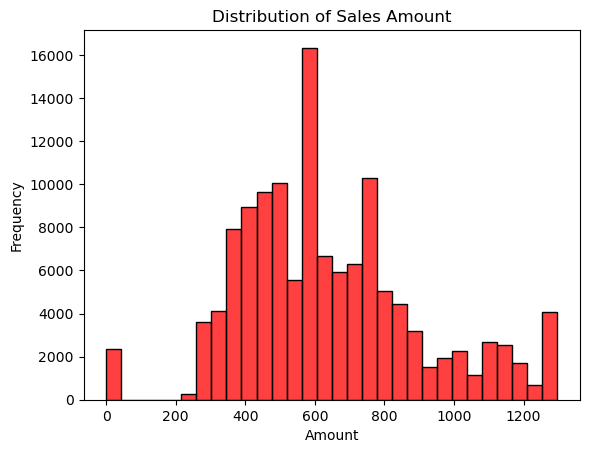

```python
# Distribution of Sales Amounts
plt.figure()
sns.histplot(data['amount'], bins=30, color = "red")
plt.title("Distribution of Sales Amount")
plt.xlabel("Amount")
plt.ylabel("Frequency")
plt.show()
```

This histogram represents the distribution of the amount (sales value) across all transactions. The x-axis shows the range of sales amounts, while the y-axis represents the frequency of transactions. It helps identify how sales values are spread and whether the data is symmetric or skewed. The concentration of bars around the mid-range indicates that most sales occur within a specific price range. The presence of bars at higher values shows the existence of high-value transactions. The distribution appears slightly right-skewed, indicating more lower-to-mid value sales than extremely high sales. This visualization is useful for understanding customer purchasing behavior. It also supports decisions related to pricing and sales strategy.

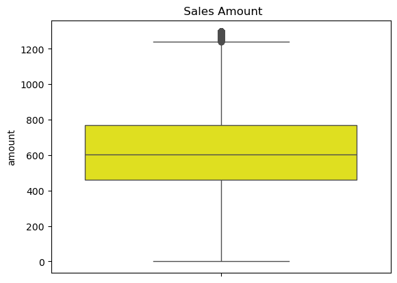

```python
#  TO DETECT OUTLIERS IN SALES AMOUNT
plt.figure()
sns.boxplot(y=data['amount'],color = "yellow")
plt.title(" Sales Amount")
plt.show()
```

This box plot is used to identify outliers and understand the spread of the sales amount data. The box represents the interquartile range (IQR), which contains the middle 50% of sales values. The line inside the box indicates the median sales amount. The whiskers show the typical minimum and maximum values within an acceptable range. Points plotted beyond the whiskers represent outliers, indicating unusually high sales transactions. These outliers can significantly affect average calculations if not handled properly. The plot helps visually confirm the presence of extreme values. It is an effective tool for deciding whether outlier treatment is required.

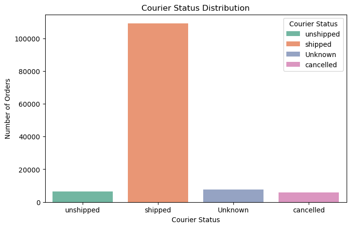

```python
# TO SEE THE COURIER STATUS DISTRIBUTION USING COUNTPLOT
plt.figure(figsize=(8,5))

ax = sns.countplot(
    x='courier_status',
    data=data,
    hue='courier_status',
    palette='Set2'
)

plt.title("Courier Status Distribution")
plt.xlabel("Courier Status")
plt.ylabel("Number of Orders")

# Manually add legend
handles = ax.patches[:data['courier_status'].nunique()]
labels = data['courier_status'].unique()
plt.legend(handles, labels, title="Courier Status")

plt.show()
```

The distribution of orders across various courier statuses is displayed in this univariate analysis graphic. A courier status category, such as shipped, unshipped, cancelled, or unknown, is represented by each bar, and the height of the bar shows how many orders fall into that category. To enhance readability and visual contrast, distinct colors are applied to each bar using the Set2 color scheme. To easily map each hue to its relevant courier status, a legend has been included. While relatively few orders fall into the cancelled or unshipped categories, it is clear from the graphic that the bulk of orders are in the shipped category, indicating effective delivery operations.

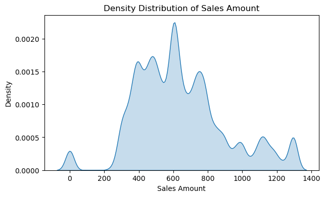

```python
plt.figure(figsize=(7,4))
sns.kdeplot(data['amount'], fill=True)
plt.title("Density Distribution of Sales Amount")
plt.xlabel("Sales Amount")
plt.ylabel("Density")
plt.show()
```

This visualization shows the probability density distribution of the sales amount. It helps understand where most sales values are concentrated. The peak of the curve represents the most frequent sales range. A long right tail indicates presence of high-value orders. This helps identify skewness in sales data. Understanding sales distribution supports pricing decisions. It also helps detect abnormal spending behavior. This is a pure univariate analysis as it involves only one variable.

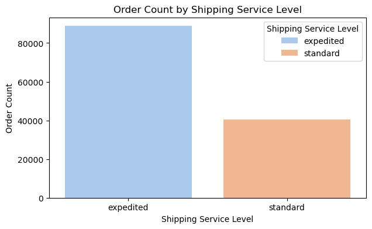

```python
# TO CHECK ORDER COUNT BY SHIPPING SERVICE LEVEL
plt.figure(figsize=(7,4))

ax = sns.countplot(
    x='ship_service_level',
    data=data,
    hue='ship_service_level',
    palette='pastel'
)

plt.title("Order Count by Shipping Service Level")
plt.xlabel("Shipping Service Level")
plt.ylabel("Order Count")

# Manually create legend
handles = ax.patches[:data['ship_service_level'].nunique()]
labels = data['ship_service_level'].unique()
plt.legend(handles, labels, title="Shipping Service Level")

plt.show()
```

The distribution of orders across various shipping service levels is depicted in this count plot employing a pastel color scheme for improved clarity and visual appeal. The height of the bar shows the total number of orders placed under that service level, and each bar represents a shipping service category (such as expedited and standard). Pastel hues are used to enhance readability without detracting from the data, which facilitates category comparison. The plot makes it clear that customers strongly favor faster delivery alternatives, as accelerated shipping is selected far more frequently than regular shipping. According to this data, consumers prefer speedy purchase fulfillment, even if it means paying more for shipping.

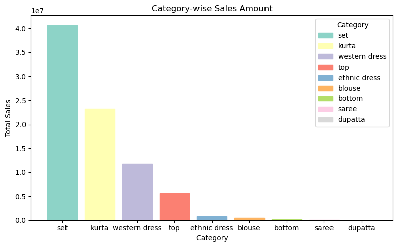

```python
# TO CHECK CATEGORY WISE SALES AMOUNT
category_sales = (
    data.groupby('category')['amount']
    .sum()
    .sort_values(ascending=False)
)

plt.figure(figsize=(8,5))

bars = plt.bar(
    category_sales.index,
    category_sales.values
)

# Apply different colors automatically
colors = plt.cm.Set3(range(len(category_sales)))
for bar, color in zip(bars, colors):
    bar.set_color(color)

# Title and labels
plt.title("Category-wise Sales Amount")
plt.xlabel("Category")
plt.ylabel("Total Sales")

# Legend
plt.legend(bars, category_sales.index, title="Category")

plt.tight_layout()
plt.show()
```

The overall sales amount for each product category is shown in this bar chart. The height of each bar, which represents a category, represents the total sales value. A colormap is used to apply different colors to each bar so that categories may be easily distinguished. To improve interpretability, a legend is included to connect each hue to its corresponding category. Comparing sales contributions across product groups and identifying high-performing categories are made easier by the graphic.

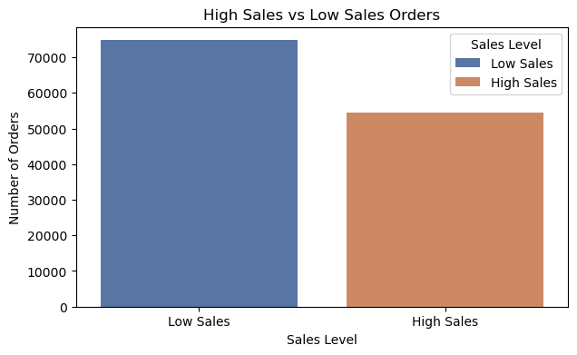

```python
# UNDERSTAND WITH THE HELP OF COUNTPLOT NUMBER OF HIGH AND LOW VALUES FROM THE AVERAGE SALES AMOUNT
plt.figure(figsize=(7,4))

ax = sns.countplot(
    x='sales_level',
    data=data,
    hue='sales_level',
    palette='deep'
)

plt.title("High Sales vs Low Sales Orders")
plt.xlabel("Sales Level")
plt.ylabel("Number of Orders")

# Manually add legend
handles = ax.patches[:data['sales_level'].nunique()]
labels = data['sales_level'].unique()
plt.legend(handles, labels, title="Sales Level")

plt.show()
```

The quantity of orders categorized under high and low sales levels is contrasted in this count plot. Sales categories are visually distinguished using different colors, and clarity is increased by adding a legend. A univariate study, the visualization aids in comprehending how order volume is distributed according to sales performance.

BIVARIATE ANALYSIS

```python
# To check the sales level
data.groupby('sales_level').size()
```

```
sales_level
High Sales    54419
Low Sales     74756
dtype: int64
```

This code groups the data based on the sales_level column created earlier and counts the number of records in each group. It helps understand how many transactions fall under high or low sales. The size() function returns the number of rows per group. This is useful for sales segmentation analysis. It validates your feature creation logic.

```python
# TO CHECK TOTAL SALES BY STATE
data.groupby('ship_state')['amount'].sum().sort_values(ascending=False)
```

```
ship_state
Maharashtra             13814172.55
Karnataka               10907545.04
Telangana                7322779.87
Uttar Pradesh            7077712.96
Tamil Nadu               6896729.37
Delhi                    4622868.77
Kerala                   4065616.47
West Bengal              3696366.67
Andhra Pradesh           3400084.62
Haryana                  2974239.99
Gujarat                  2893007.86
Rajasthan                1815337.51
Madhya Pradesh           1660793.58
Bihar                    1487310.60
Odisha                   1459125.07
Punjab                   1366541.20
Assam                    1078786.70
Uttarakhand              1022105.80
Jharkhand                 962389.64
Unknown                   705241.27
Goa                       663733.87
Chattisgarh               576608.85
Himachal Pradesh          539790.01
Jammu and Kashmir         523404.67
Manipur                   221199.49
Andaman and Nico.In.      207406.57
Sikkim                    146833.66
Pondicherry               146563.41
Nagaland                  142310.17
Megalaya                  125941.31
Chandigarh                109686.06
Arunachal Pradesh         100927.00
Tripura                    98493.90
Mizoram                    43869.71
Daman and Diu              23430.04
Dadra and Nagar Hav.       23308.38
Lakshadweep                 3175.29
Name: amount, dtype: float64
```

This code groups the dataset by ship_state and calculates the total sales amount for each state. The sum() function aggregates sales values within each group. Sorting in descending order highlights the highest revenue-generating states. This provides a clearer picture than simple order counts. It combines categorical and numerical data. This is a classic bivariate analysis technique.

```python
# TO CALCULATE AVERAGE SALES BY FULFILLMENT TYPE
data.groupby('fulfillment')['amount'].mean()
```

```
fulfillment
amazon      642.464732
merchant    640.811249
Name: amount, dtype: float64
```

This code calculates the average sales amount for each fulfillment type. It helps compare whether Amazon-fulfilled or merchant-fulfilled orders generate higher average sales. Mean sales value gives insight into customer spending behavior. This comparison supports operational decisions. It is useful for performance benchmarking.

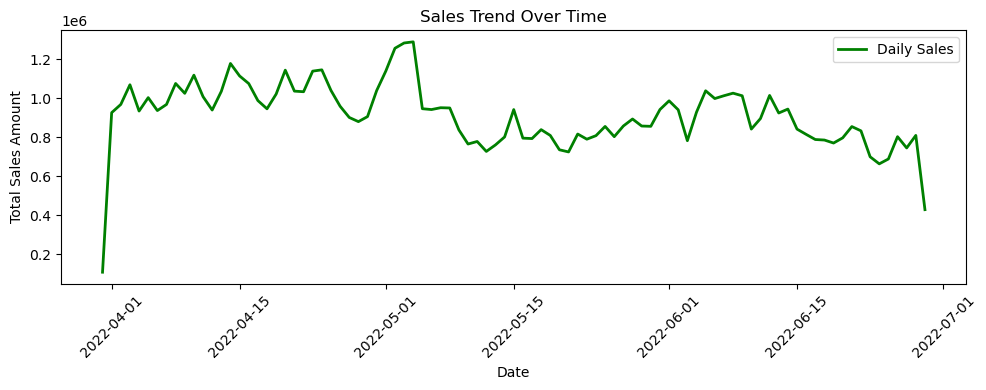

```python
# TO CHECK DAILY SALES TREND OVER TIME
import matplotlib.pyplot as plt
import pandas as pd

# Ensure date column is datetime
data['parsed_date'] = pd.to_datetime(data['parsed_date'])

# Group by date and sort
daily_sales = data.groupby('parsed_date')['amount'].sum().sort_index()

plt.figure(figsize=(10,4))

plt.plot(
    daily_sales.index,
    daily_sales.values,
    color='green',
    linewidth=2,
    label='Daily Sales'
)

plt.title("Sales Trend Over Time")
plt.xlabel("Date")
plt.ylabel("Total Sales Amount")

# Improve date formatting
plt.xticks(rotation=45)
plt.legend()
plt.tight_layout()

plt.show()
```

The daily sales trend over time is seen in this line graph. To guarantee precise chronological graphing, the date column is transformed into the appropriate datetime format. Every day, sales figures are combined and displayed against time to clearly see patterns, variations, and abnormalities in sales performance. The x-axis is easier to read when dates are formatted and rotated correctly, which makes the visualization appropriate for reporting and analysis

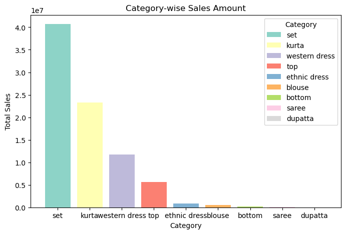

```python
# TO SEE THE SALES AMOUNT ACCORDING TO THE CATEGORY
plt.figure(figsize=(8,5))

category_sales = (
    data.groupby('category')['amount']
    .sum()
    .sort_values(ascending=False)
)

bars = plt.bar(
    category_sales.index,
    category_sales.values,
    color=plt.cm.Set3(range(len(category_sales)))
)

plt.title("Category-wise Sales Amount")
plt.xlabel("Category")
plt.ylabel("Total Sales")

# Legend
plt.legend(bars, category_sales.index, title="Category")

plt.show()
```

Based on the combined transaction data, this bar chart shows the overall sales amount per category. Each bar denotes a different product category, and the height of the bar reflects the total sales revenue for that category. Each bar has a different color to help differentiate between categories, and the legend makes it easy to understand which color corresponds to which group. The graphic shows which product groupings contribute the most to total income, making it easy to distinguish between high- and low-performing categories. While shorter bars draw attention to sectors with a smaller revenue contribution, taller bars represent categories with stronger sales success.

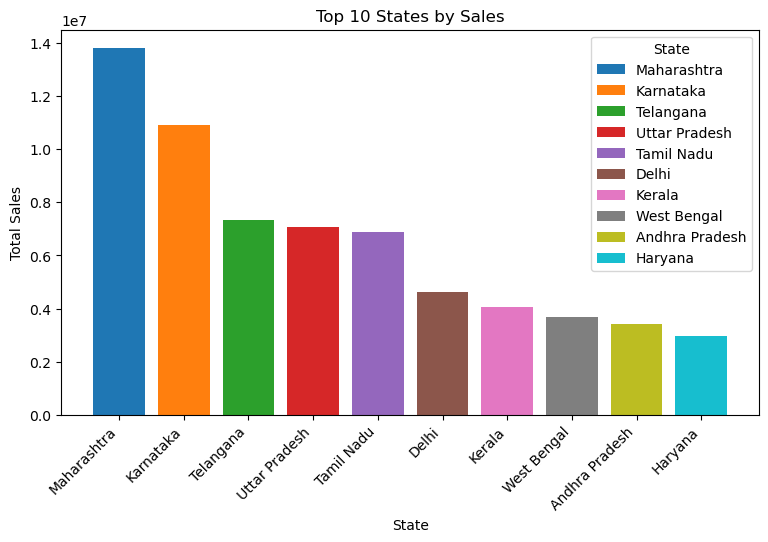

```python
# TO ChECK THE SALES OF STATES USING BAR CHART
plt.figure(figsize=(9,5))

state_sales = (
    data.groupby('ship_state')['amount']
    .sum()
    .sort_values(ascending=False)
    .head(10)
)

bars = plt.bar(
    state_sales.index,
    state_sales.values,
    color=plt.cm.tab10(range(len(state_sales)))  # bold & distinct colors
)

plt.title("Top 10 States by Sales")
plt.xlabel("State")
plt.ylabel("Total Sales")

plt.xticks(rotation=45, ha='right')
# Legend
plt.legend(bars, state_sales.index, title="State")

plt.show()
```

This bar chart displays the top 10 states by total sales amount, highlighting regional sales performance. The height of each bar, which stands for a state, indicates the total amount of sales from that state. The legend links each hue to its appropriate state for simple identification, and each bar uses bold, unique colors to clearly distinguish between states. By displaying which states make up the largest portion of total revenues, the graphic assists in identifying important revenue-generating regions. Stronger market demand and increased consumer activity are indicated by states with taller bars.

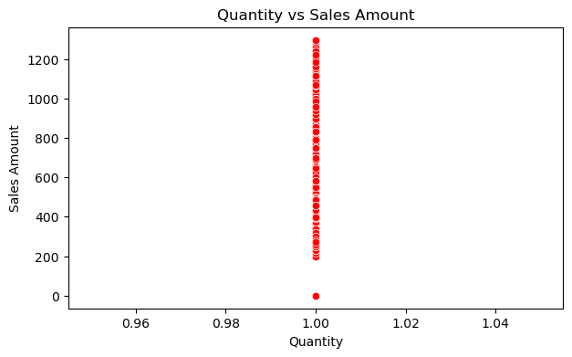

```python
plt.figure(figsize=(7,4))
sns.scatterplot(x='qty', y='amount', data=data,color='red')
plt.title("Quantity vs Sales Amount")
plt.xlabel("Quantity")
plt.ylabel("Sales Amount")
plt.show()
```

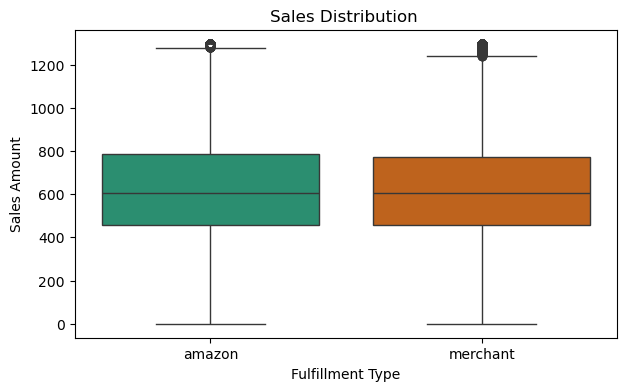

```python
# TO CHECK THE SALES DISTRIBUTION BY ITS FULFILLMENT TYPE
plt.figure(figsize=(7,4))

ax = sns.boxplot(
    x='fulfillment',
    y='amount',
    data=data,
    hue='fulfillment',
    palette='Dark2'
)

plt.title("Sales Distribution ")
plt.xlabel("Fulfillment Type")
plt.ylabel("Sales Amount")

plt.show()
```

The distribution of sales amounts among various fulfillment types is seen in this box plot. A fulfillment category is represented by each box, which displays the sales value variability, median, and interquartile range.The plot aids in understanding the variation among fulfillment methods, comparing sales consistency, and identifying outliers. Sales numbers are more variable for fulfillment kinds with longer whiskers or broader boxes. Because it looks at the association between a numerical variable (sales quantity) and a categorical variable (fulfillment kind), this study is bivariate.

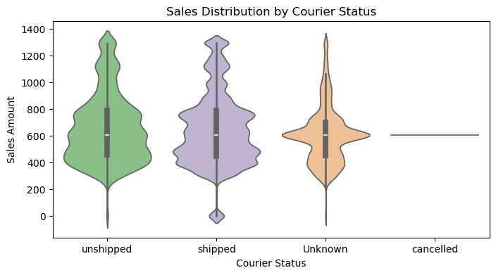

```python
plt.figure(figsize=(8,4))

ax = sns.violinplot(
    x='courier_status',
    y='amount',
    data=data,
    hue='courier_status',
    palette='Accent'
)

plt.title("Sales Distribution by Courier Status")
plt.xlabel("Courier Status")
plt.ylabel("Sales Amount")

plt.show()
```

The distribution of sales quantities across various courier statuses is seen in this violin plot. The density, spread, and central tendency of sales values are shown for each violin, which stands for a courier status category. A violin's wider portions show a greater concentration of sales values at that level, but its narrower sections show fewer observations. Comparisons of sales distribution patterns and delivery status fluctuation are made possible by this visualization. This bivariate analysis looks at the connection between sales quantity (numerical) and courier status (categorical).

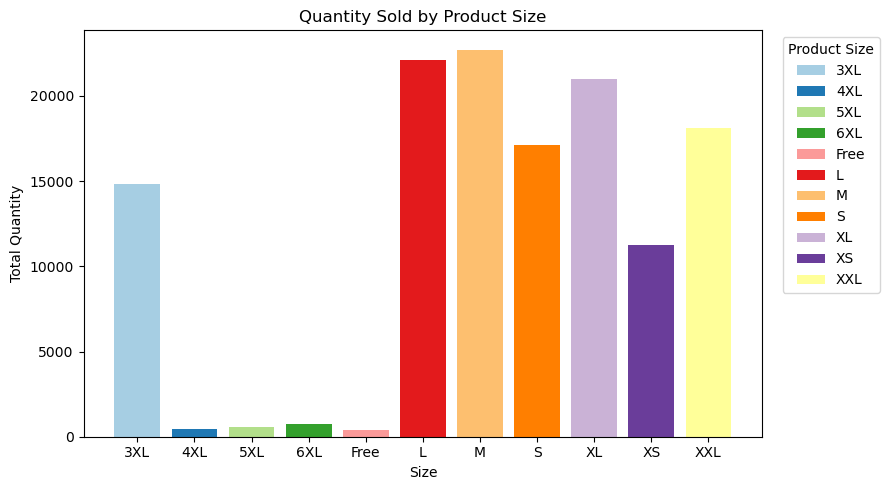

```python
plt.figure(figsize=(9,5))

size_qty = data.groupby('size')['qty'].sum()

bars = plt.bar(
    size_qty.index,
    size_qty.values,
    color=plt.cm.Paired(range(len(size_qty)))
)

plt.title("Quantity Sold by Product Size")
plt.xlabel("Size")
plt.ylabel("Total Quantity")

# Move legend to the right side
plt.legend(
    bars,
    size_qty.index,
    title="Product Size",
    bbox_to_anchor=(1.02, 1),
    loc='upper left'
)

plt.tight_layout()
plt.show()
```

The total quantity sold across various product sizes is shown in this bar chart. Each bar represents a certain size category, while the bar's height represents the total number of units sold. To clearly distinguish between different product sizes, distinct colors are utilized for each bar, and the legend associates each color with a corresponding size. This graphic aids in determining the most popular product sizes among consumers. Higher demand is indicated by sizes with taller bars, which helps with stock management and inventory planning.

MULTIVARIATE ANALYSIS

```python
# TO check State-wise Sales by Sales Level
data.groupby(['ship_state', 'sales_level'])['amount'].sum()
```

```
ship_state            sales_level
Andaman and Nico.In.  High Sales      116592.80
                      Low Sales        90813.77
Andhra Pradesh        High Sales     1924809.56
                      Low Sales      1475275.06
Arunachal Pradesh     High Sales       68267.57
                                        ...
Uttar Pradesh         Low Sales      2626031.65
Uttarakhand           High Sales      618299.66
                      Low Sales       403806.14
West Bengal           High Sales     1979391.71
                      Low Sales      1716974.96
Name: amount, Length: 73, dtype: float64
```

```python
# CALCULATE CORRELATION MATRIX
correlation = data[
    ['Courier status encoded',
     'fulfillment encoded',
     'ship_service_level encoded',
     'amount',
     'ship_city encoded',
     'ship_state encoded']
].corr()

# DISPLAY THE CORRELATION VALUES
correlation
```

|  | Courier status encoded | fulfillment encoded | ship_service_level encoded | amount | ship_city encoded | ship_state encoded |
| --- | --- | --- | --- | --- | --- | --- |
| Courier status encoded | 1.000000 | 0.469547 | 0.463650 | 0.022463 | -0.001666 | -0.003165 |
| fulfillment encoded | 0.469547 | 1.000000 | 0.980479 | -0.002922 | 0.004562 | -0.005202 |
| ship_service_level encoded | 0.463650 | 0.980479 | 1.000000 | -0.038630 | 0.005480 | -0.006899 |
| amount | 0.022463 | -0.002922 | -0.038630 | 1.000000 | -0.009312 | -0.006109 |
| ship_city encoded | -0.001666 | 0.004562 | 0.005480 | -0.009312 | 1.000000 | -0.023643 |
| ship_state encoded | -0.003165 | -0.005202 | -0.006899 | -0.006109 | -0.023643 | 1.000000 |

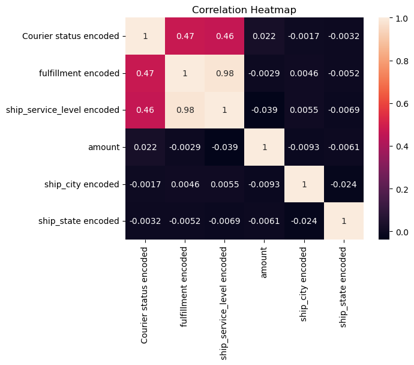

```python
corr = data[['Courier status encoded', 'fulfillment encoded', 'ship_service_level encoded','amount','ship_city encoded','ship_state encoded']].corr()

sns.heatmap(corr, annot=True)
plt.title("Correlation Heatmap")
plt.show()
```

This heatmap represents the correlation matrix calculated using the corr() function for selected encoded variables and sales amount. It shows the numerical relationship between courier status, fulfillment type, shipping service level, amount, city, and state. A strong positive correlation is observed between fulfillment encoded and ship_service_level encoded, indicating that fulfillment type strongly influences shipping service selection. Courier status encoded also shows a moderate positive correlation with fulfillment and shipping service level. The amount variable has a very weak correlation with most encoded variables, suggesting sales value is not highly dependent on logistics-related features. City and state encoded variables show near-zero correlation, meaning geographical encoding has minimal linear impact on sales amount. This heatmap helps in understanding relationships before visualization. It is part of Exploratory Data Analysis (EDA) and helps in identifying feature relevance.

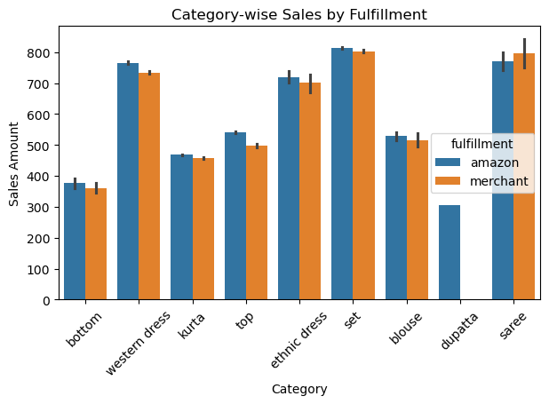

```python
plt.figure(figsize=(7,4))
sns.barplot(x='category', y='amount', hue='fulfillment', data=data)
plt.title("Category-wise Sales by Fulfillment")
plt.xlabel("Category")
plt.ylabel("Sales Amount")
plt.xticks(rotation=45)
plt.show()
```

This chart shows how fulfillment impacts category sales. Helps identify best fulfillment per category. Supports operational alignment. Useful for service planning. Improves customer experience. Shows multi-factor interaction. Good strategic insight.

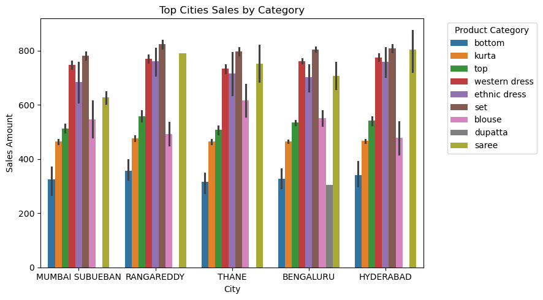

```python
# Identify top 5 cities by total sales
top_cities = (
    data.groupby('ship_city')['amount']
    .sum()
    .sort_values(ascending=False)
    .head(5)
    .index
)

# Filter data for top cities only
filtered = data[data['ship_city'].isin(top_cities)]

# Create bar plot
plt.figure(figsize=(9,5))

sns.barplot(
    x='ship_city',
    y='amount',
    hue='category',
    data=filtered
)

# Chart titles and labels
plt.title("Top Cities Sales by Category", fontsize=12)
plt.xlabel("City")
plt.ylabel("Sales Amount")

# Move legend outside the plot to avoid overlap
plt.legend(
    title="Product Category",
    bbox_to_anchor=(1.05, 1),
    loc='upper left'
)

# Adjust layout for clean appearance
plt.tight_layout()

plt.show()
```

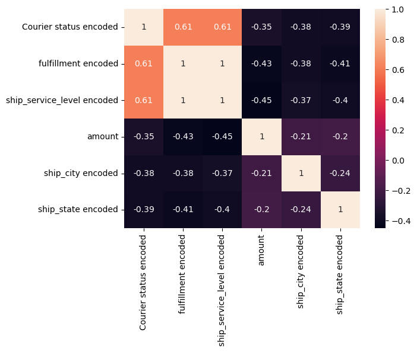

```python
sns.heatmap(corr.corr(), annot=True)
```